# Worksheet 1: Decision Trees

Jeevitha Bandi

# Load necessary libraries

#install.packages(“dplyr”)

### Exercise 1: Classification and Pruning

This problem involves the OJ data set which is part of the `ISLR2` package.

1. Create a training set containing a random sample of 800 observations, and a test set containing the remaining observations.

```r
set.seed(123)
train_indices <- sample(1:nrow(OJ), 800)

OJ_train <- OJ[train_indices, ]
OJ_test <- OJ[-train_indices, ]

cat("Training set size:", nrow(OJ_train), "\n")
```

```
## Training set size: 800
```

```r
cat("Test set size:", nrow(OJ_test))
```

```
## Test set size: 270
```

2. Fit a tree to the training data, with Purchase as the response and the other variables as predictors. Use the `summary()` function to produce summary statistics about the tree, and describe the results obtained. What is the training error rate? How many terminal nodes does the tree have?

```r
library(tree)
tree_OJ <- tree(Purchase ~ ., data = OJ_train)
summary(tree_OJ)
```

```
##
## Classification tree:
## tree(formula = Purchase ~ ., data = OJ_train)
## Variables actually used in tree construction:
## [1] "LoyalCH"   "PriceDiff"
## Number of terminal nodes:  8
## Residual mean deviance:  0.7625 = 603.9 / 792
## Misclassification error rate: 0.165 = 132 / 800
```

```r
pred_train <- predict(tree_OJ, OJ_train, type = "class")
train_error <- mean(pred_train != OJ_train$Purchase)

cat("Training error rate:", round(train_error, 4), "\n")
```

```
## Training error rate: 0.165
```

```r
cat("Number of terminal nodes (leaves):", sum(tree_OJ$frame$var == "<leaf>"))
```

```
## Number of terminal nodes (leaves): 8
```

3. Type in the name of the tree object in order to get a detailed text output. Pick one of the terminal nodes, and interpret the information displayed.

```r
tree_OJ
```

```
## node), split, n, deviance, yval, (yprob)
##       * denotes terminal node
##
##  1) root 800 1071.00 CH ( 0.60875 0.39125 )
##    2) LoyalCH < 0.5036 350  415.10 MM ( 0.28000 0.72000 )
##      4) LoyalCH < 0.276142 170  131.00 MM ( 0.12941 0.87059 )
##        8) LoyalCH < 0.0356415 56   10.03 MM ( 0.01786 0.98214 ) *
##        9) LoyalCH > 0.0356415 114  108.90 MM ( 0.18421 0.81579 ) *
##      5) LoyalCH > 0.276142 180  245.20 MM ( 0.42222 0.57778 )
##       10) PriceDiff < 0.05 74   74.61 MM ( 0.20270 0.79730 ) *
##       11) PriceDiff > 0.05 106  144.50 CH ( 0.57547 0.42453 ) *
##    3) LoyalCH > 0.5036 450  357.10 CH ( 0.86444 0.13556 )
##      6) PriceDiff < -0.39 27   32.82 MM ( 0.29630 0.70370 ) *
##      7) PriceDiff > -0.39 423  273.70 CH ( 0.90071 0.09929 )
##       14) LoyalCH < 0.705326 130  135.50 CH ( 0.78462 0.21538 )
##         28) PriceDiff < 0.145 43   58.47 CH ( 0.58140 0.41860 ) *
##         29) PriceDiff > 0.145 87   62.07 CH ( 0.88506 0.11494 ) *
##       15) LoyalCH > 0.705326 293  112.50 CH ( 0.95222 0.04778 ) *
```

4. Create a plot of the tree, and interpret the results.

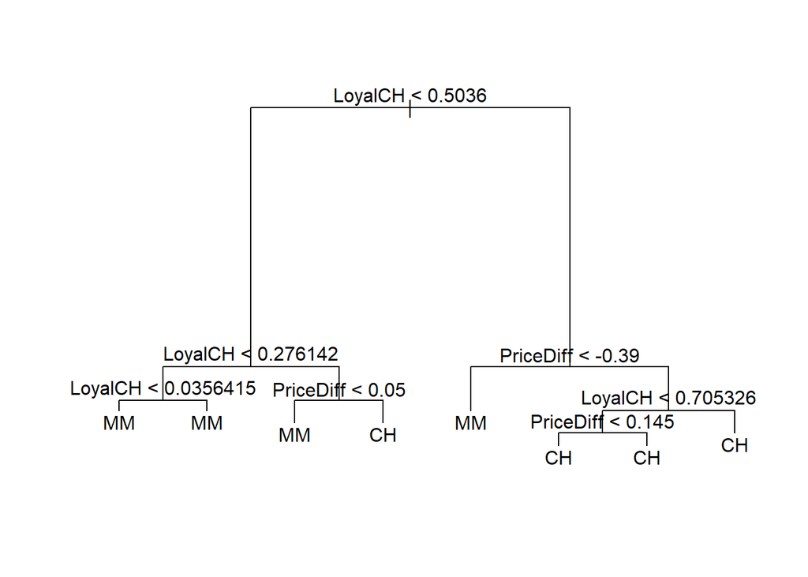

```r
plot(tree_OJ)
text(tree_OJ, pretty = 0)
```

5. Predict the response on the test data, and produce a confusion matrix comparing the test labels to the predicted test labels. What is the test error rate?

```r
pred <- predict(tree_OJ, OJ_test, type = "class")

conf_matrix <- table(Predicted = pred, Actual = OJ_test$Purchase)
conf_matrix
```

```
##          Actual
## Predicted  CH  MM
##        CH 150  34
##        MM  16  70
```

```r
test_error <- mean(pred != OJ_test$Purchase)
cat("Test error rate:", round(test_error, 4))
```

```
## Test error rate: 0.1852
```

6. Apply the `cv.tree()` function to the training set in order to determine the optimal tree size.

```r
set.seed(123)  # for reproducibility
cv_oj <- cv.tree(tree_OJ, FUN = prune.misclass)
cv_oj
```

```
## $size
## [1] 8 5 3 2 1
##
## $dev
## [1] 139 139 157 167 313
##
## $k
## [1] -Inf    0    8   11  154
##
## $method
## [1] "misclass"
##
## attr(,"class")
## [1] "prune"         "tree.sequence"
```

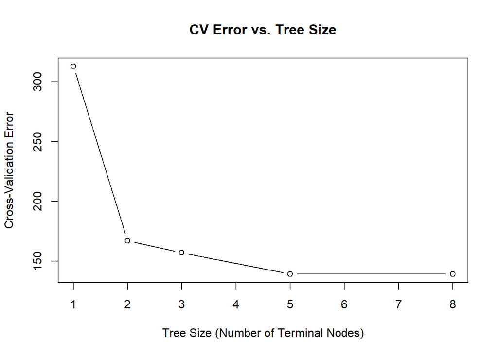

```r
plot(cv_oj$size, cv_oj$dev, type = "b", xlab = "Tree Size (Number of Terminal Nodes)", ylab = "Cross-Validation Error", main = "CV Error vs. Tree Size")
```

7. Produce a plot with tree size on the x-axis and cross-validated classification error rate on the y-axis.

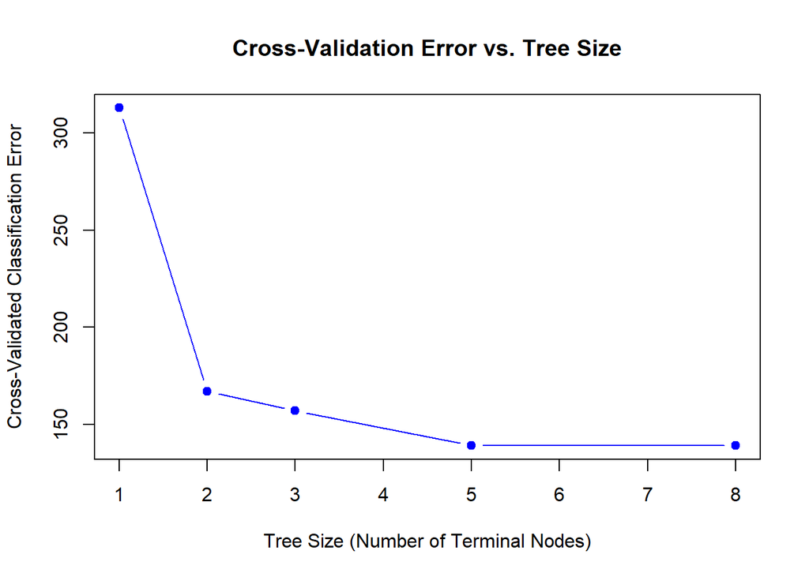

```r
plot(cv_oj$size, cv_oj$dev, type = "b", pch = 19, col = "blue", xlab = "Tree Size (Number of Terminal Nodes)", ylab = "Cross-Validated Classification Error", main ="Cross-Validation Error vs. Tree Size")
```

8. Which tree size corresponds to the lowest cross-validated classification error rate?

```r
min_err <- which.min(cv_oj$dev)
optimal_size <- cv_oj$size[min_err]

cat("The optimal tree size is:", optimal_size, "\n")
```

```
## The optimal tree size is: 8
```

```r
cat("corresponding to the lowest cross-validated classification error rate of:",round(cv_oj$dev[min_err], 4))
```

```
## corresponding to the lowest cross-validated classification error rate of: 139
```

1. Produce a pruned tree corresponding to the optimal tree size obtained using cross-validation. If cross-validation does not lead to selection of a pruned tree, then create a pruned tree with five terminal nodes.

```r
max_size <- max(cv_oj$size)

if (optimal_size < max_size) {
  pruned_tree <- prune.misclass(tree_OJ, best = optimal_size)
  cat("Pruned to optimal size from cross-validation:", optimal_size, "\n")
} else {
  # Cross-validation suggests no pruning; prune to 5 nodes manually
  pruned_tree <- prune.misclass(tree_OJ, best = 5)
  cat("Cross-validation did not suggest pruning, so pruned to 5 terminal nodes.\n")
}
```

```
## Cross-validation did not suggest pruning, so pruned to 5 terminal nodes.
```

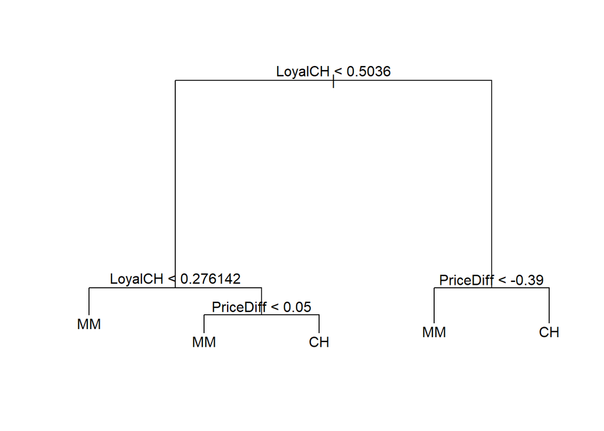

```r
plot(pruned_tree)
text(pruned_tree, pretty = 0)
```

10. Compare the training error rates between the pruned and unpruned trees. Which is higher?

```r
# unpruned tree
pred_unpruned <- predict(tree_OJ, OJ_train, type = "class")
err_unpruned <- mean(pred_unpruned != OJ_train$Purchase)

# pruned tree
pred_pruned <- predict(pruned_tree, OJ_train, type = "class")
err_pruned <- mean(pred_pruned != OJ_train$Purchase)

cat("Training error rate (Unpruned Tree):", round(err_unpruned, 4), "\n")
```

```
## Training error rate (Unpruned Tree): 0.165
```

```r
cat("Training error rate (Pruned Tree):", round(err_pruned, 4), "\n")
```

```
## Training error rate (Pruned Tree): 0.165
```

11. Compare the test error rates between the pruned and unpruned trees. Which is higher?

```r
# npruned tree
predUnpruned <- predict(tree_OJ, OJ_test, type = "class")
unpruned_err <- mean(predUnpruned != OJ_test$Purchase)

# pruned tree
predPruned <- predict(pruned_tree, OJ_test, type = "class")
pruned_err <- mean(predPruned != OJ_test$Purchase)

cat("Test error rate (Unpruned Tree):", round(unpruned_err, 4), "\n")
```

```
## Test error rate (Unpruned Tree): 0.1852
```

```r
cat("Test error rate (Pruned Tree):", round(pruned_err, 4), "\n")
```

```
## Test error rate (Pruned Tree): 0.1852
```

### Exercise 2: Decision Trees for Regression

In the lab, a classification tree was applied to the Carseats data set after converting Sales into a qualitative response variable. Now we will seek to predict Sales using regression trees and related approaches, treating the response as a quantitative variable.

1. Split the data set into a training set and a test set.

```r
library(ISLR2)
data(Carseats)
set.seed(123)

train_ind <- sample(1:nrow(Carseats), nrow(Carseats) / 2)
train <- Carseats[train_ind, ]
test <- Carseats[-train_ind, ]

cat("Training set size:", nrow(train), "\n")
```

```
## Training set size: 200
```

```r
cat("Test set size:", nrow(test))
```

```
## Test set size: 200
```

2. Fit a regression tree to the training set. Plot the tree, and interpret the results. What test MSE do you obtain?

```r
library(tree)

reg <- tree(Sales ~ ., data = train)
summary(reg)
```

```
##
## Regression tree:
## tree(formula = Sales ~ ., data = train)
## Variables actually used in tree construction:
## [1] "ShelveLoc"   "Price"       "Income"      "Age"         "Population"
## [6] "Education"   "CompPrice"   "Advertising"
## Number of terminal nodes:  18
## Residual mean deviance:  2.132 = 388.1 / 182
## Distribution of residuals:
##     Min.  1st Qu.   Median     Mean  3rd Qu.     Max.
## -4.08000 -0.92870  0.06244  0.00000  0.87020  3.71700
```

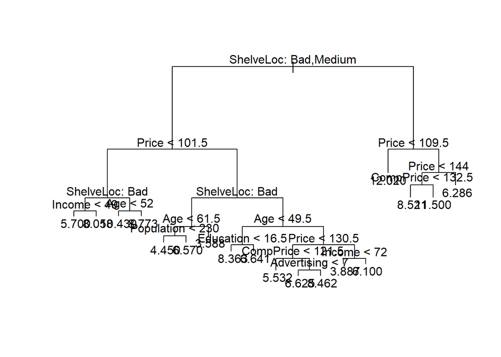

```r
plot(reg)
text(reg, pretty = 0)
```

```r
predictions <- predict(reg, newdata = test)


test_mse <- mean((predictions - test$Sales)^2)
cat("Test MSE:", round(test_mse, 4))
```

```
## Test MSE: 4.3954
```